# tmpkmre1cmy

## 思想剧场：时间裂缝里的对话

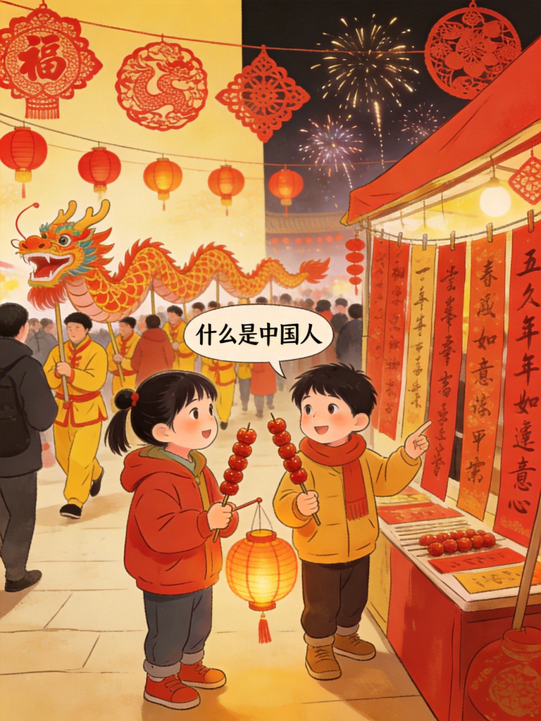

## 第一课时：顾炎武的“匹夫有责”——每个人的文明接力棒

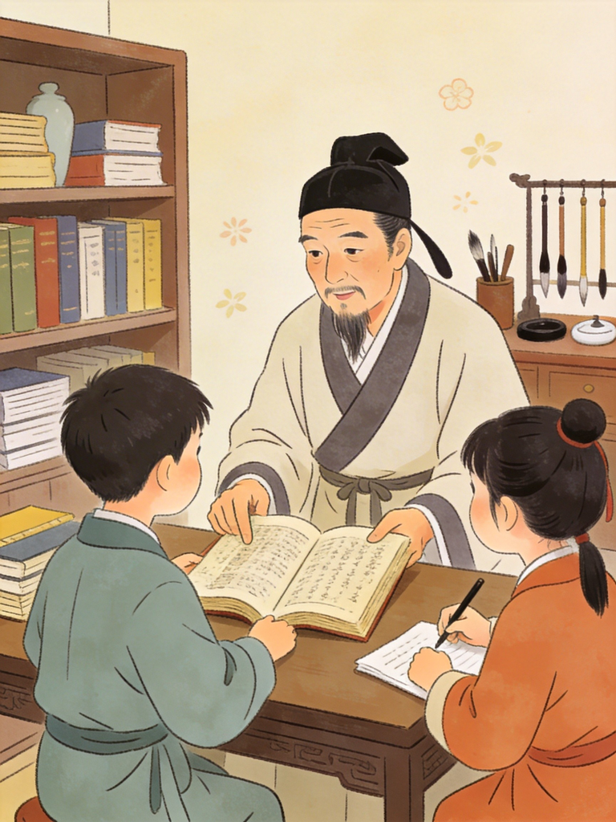

## 第二课时：黄宗羲的“权力诊断书”——给权力装上刹车

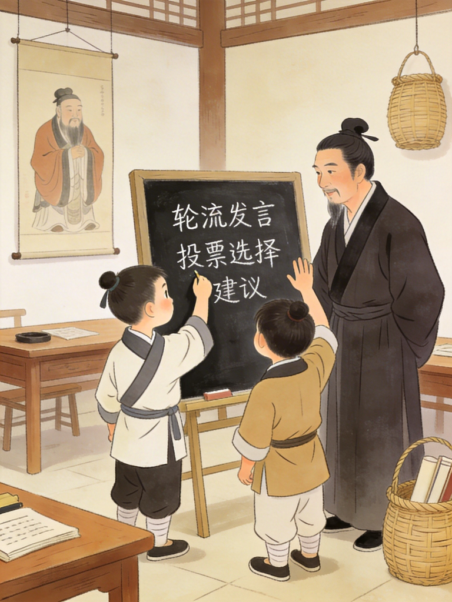

## 第三课时：龚自珍的“呐喊与创造”——变革需要智慧和勇气

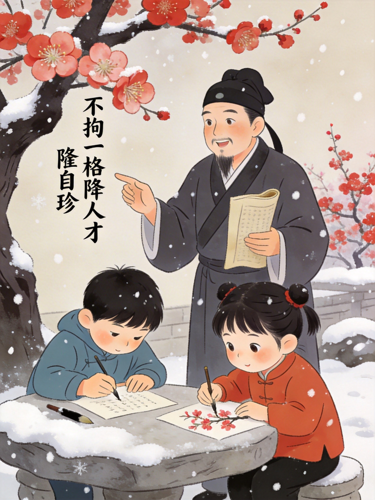

# 第十一章：如何当一个“现代中国人”？——明清之际的启蒙探险

**时间**：2026年春季，历史博物馆“明清思想展”现场  
**地点**：互动体验区“时空对话亭”  
**人物**： -

**小启**（12岁，对历史充满好奇，总爱问“为什么”） - **小蒙**（11岁，逻辑性强，喜欢分析规则） - **小变**（10岁，创意十足，讨厌一成不变） - **虚拟导览员**（AI生成的三位思想家全息投影） — ### 第一幕：穿越时空的疑问 【场景】 博物馆的“时空对话亭”里，三个孩子戴上VR眼镜，眼前出现了三位明清学者：顾炎武、黄宗羲、龚自珍。 **小启**：（兴奋）哇！真的能对话吗？顾先生，我有个问题——你们生活在几百年前，说的话对我们现代人还有用吗？

**顾炎武**：（微笑）时间会变，但人心不变。你们今天遇到的困惑——公平、责任、权力——我们在三百年前就在思考了。

**小蒙**：（推了推眼镜）黄先生，我在历史课上学到您说“天下之大害者，君而已矣”。您当时不怕被杀头吗？

**黄宗羲**：（目光坚定）真理比生命更重。如果因为害怕就不说真话，文明就停止了。

**小变**：（举手）龚先生，您写“我劝天公重抖擞”的时候，是不是觉得周围人都像在睡觉？

**龚自珍**：（苦笑）是的。但呐喊的意义，就是叫醒一个算一个。

**小启**：所以你们三位，就像“现代中国人”的启蒙老师？

**顾炎武**：误解了。“责”是**做该做的事**。比如： - 朋友让你考试作弊，你拒绝 - 看到校园霸凌，你报告老师 - 网上有谣言，你核实再转发

**小变**：那如果我不做呢？世界会毁灭吗？

**顾炎武**：不会。但文明像沙堡，每人少放一粒沙就矮一点，多放一粒就高一点。

**小启**：（思考）所以“尽责”就像维护我们的“文明沙堡”？

**顾炎武**：正是。

**小蒙**：黄先生，您设计的“学校议政”🌟听起来很酷，但真的有用吗？学生说话，大人会听吗？

**黄宗羲**：权力像流水，堵则溃，疏则通。让学生说话是**安全阀**。现在不听小的声音，将来就要听大的爆炸。

**小变**：龚先生，您总说“变”，但变坏了怎么办？比如我们班换了新班规，结果更乱了。

**龚自珍**：问得好！“变法”🌟不是乱变，是**诊断后开药**。先问： 1. 旧规则哪里痛？（问题诊断） 2. 新规则能止痛吗？（方案验证） 3. 有副作用怎么办？（风险评估）

**小启**：所以你们三位，一个教我们“尽责”，一个教我们“监督权力”，一个教我们“智慧变革”？

**小启**：（犹豫）可是，如果尽责却没人看到，那还有意义吗？

**顾炎武**：（温和）意义不在别人的眼光，而在你心里那盏灯是否亮着。尽责是对自己良心的交代，就像你偷偷把同学掉的钱包放回失物招领处——没人看见，但你知道自己做对了。

**小蒙**：（推眼镜思考）那我该选哪条路呢？是像顾先生那样默默尽责，还是像黄先生那样监督权力？或者像龚先生那样推动变革？

**小变**：（兴奋举手）我觉得变革更需要勇气！像龚先生那样喊出来！这让我想起我们班上次选班长，有的同学只会抱怨，有的同学却提出了具体的改进方案——后者才是真正的变革者！

**虚拟导览员**：（AI声音）很好的思考！这就是现代中国人的多元选择——没有标准答案，只有适合你的道路。现在，让我们进入深度探险。 — ### 哲人小故事：顾炎武的“十年徒步地图” 顾炎武有个习惯——**走路**。他花十年徒步走遍大半个中国，做“田野调查”。他边走边记：土地为什么荒废？百姓为什么贫困？官员怎么收税？ 学生问他：“为什么走这么多路？” 顾炎武回答：“**纸上得来终觉浅，绝知此事要躬行。**” 意思是：光看书本不够，必须亲自实践。

**启发**：顾炎武的“匹夫有责”不是空谈，是

**用脚步丈量出来的责任**。就像你要了解班级问题，不能只听别人说，得自己观察、记录、分析。 ### 🌟 核心概念解读 **“天下兴亡匹夫有责”**不是口号，是**行动哲学**。顾炎武生活在明朝灭亡、清朝入关的动荡年代，他看到很多读书人只会空谈道理，遇到大事却躲起来。于是他说：文明不是皇帝一个人的事，是每个普通人的事。他的“经世致用”🌟思想强调学问要解决实际问题，不能纸上谈兵。 **儿童比喻**：就像班级大扫除，每个人都有自己的“责任区”。你可以选择认真打扫，也可以偷懒。但如果每个人都偷懒，教室就变成垃圾场。 ### 思想剧场延伸：校园里的“尽责时刻”

**小启**：顾先生，我在想——如果看到同学在墙上乱画，我该制止吗？这不是我的责任区啊。

**顾炎武**：墙是大家的墙，画坏了影响所有人。你有两个选择： 1. 当面制止（可能冲突） 2. 告诉老师（间接维护）

**小蒙**：那如果制止了，对方说“多管闲事”呢？

**顾炎武**：问他：“如果这是你家的墙，你愿意别人乱画吗？” 如果他说“不愿意”，你就说：“学校的墙，是我们共同的‘家墙’。”

**小变**：我懂了！责任不是“管闲事”，是“管共同的事”。

### 实践工具箱：我的“责任区”地图 请画出你的“责任区”地图，包括： - **家庭区**：收拾书桌、照顾宠物、对家人友善 -

**学校区**：认真听课、维护公物、帮助同学 -

**公共区**：遵守交通规则、不乱扔垃圾、文明上网

**完成样例**： > 姓名：小启  
> 本周责任记录： > - 周二：提醒同桌考试不要偷看（学校区） > - 周四：把小区游乐场的碎玻璃捡走（公共区） > - 周六：教弟弟垃圾分类（家庭区） > **感受**：原来小小的行动，真的能让周围变好一点点。 ### 哲人趣味问答：顾炎武的“责任小测验” 1.

**情境题**：课间休息时，你看见水龙头没关紧，水一直在流。你会： - A. 马上关掉，并在旁边贴个“请节约用水”的小纸条 - B. 关掉就走 - C. 想“又不是我开的”，不管 - D. 报告老师让老师处理

**顾炎武点评**：选A是“尽责+”——不仅解决问题，还预防未来问题；选B是基本尽责；选C是“责任盲区”；选D是转移责任，但比C好。 2.

**辩论题**：“匹夫有责”会不会让小孩子压力太大？ -

**正方**：会。小孩应该无忧无虑，责任是大人的事。 -

**反方**：不会。从小学习负责，长大才不会是“责任巨婴”。

**你的立场**：________________

**理由**：________________ 3.

**创意题**：设计一个“责任接力赛”游戏，让全班同学参与。写出至少三条规则。 — ### 哲人小故事：黄宗羲的“爸爸的教训” 黄宗羲的父亲黄尊素因批评太监魏忠贤被折磨致死，那时黄宗羲16岁。 父亲临终前说：“不要恨，要**理解为什么**——为什么好人会被害？权力为何失控？” 这句话成了黄宗羲一生的研究课题。他写《明夷待访录》是在**诊断**：像医生解剖一样，分析明朝制度哪里出毛病。

**启发**：黄宗羲的批判不是情绪发泄，是

**理性分析**。就像你看到班级规则不公平，不要只是生气，要像小侦探一样收集证据、分析原因、提出改进方案。 ### 🌟 核心概念解读 黄宗羲经历了明朝腐败、清朝统治，深刻认识到：**绝对的权力会导致绝对的腐败**。他写《明夷待访录》，就像给权力做“体检报告”，找出病症、开药方。 **儿童比喻**：权力像一辆没有刹车的自行车，下坡时很爽，但随时可能撞墙。黄宗羲要给它装刹车（分权制衡）、后视镜（监督机制）、铃铛（公众舆论）。 ### 思想剧场延伸：班级里的“权力实验”

**小蒙**：黄先生，我们班选班长，总是老师指定。这算“权力私有化”吗？

**黄宗羲**：算。权力来源应该是同学们的同意，不是老师的赐予。我建议： 1.

**提名阶段**：任何同学都可以自荐或推荐他人 2.

**辩论阶段**：候选人发表“施政纲领”，回答提问 3.

**投票阶段**：匿名投票，当场计票 4.

**试用阶段**：任期三个月，可被罢免

**小变**：那如果选出来的人不好，怎么办？

**黄宗羲**：这就是“学校议政”🌟的关键——

**定期问责**。每月一次“班级议会”，班长汇报工作，同学提问。如果多数人不满，可以启动罢免程序。 **小启**：这不就是古代的“书院议政”吗？

**黄宗羲**：对！智慧穿越时空。

### 实践工具箱：设计你的“班级宪法” 和同学一起，为班级设计一份“宪法”，包括： - **权力来源**：班长如何产生？ -

**权力分工**：班长、学习委员、卫生委员各管什么？ -

**监督机制**：如何防止权力滥用？ -

**修改程序**：宪法本身如何修改？

**完成样例**： >

**阳光小学五年级（2）班宪法（草案）**  
> 第一条：班长由全班同学匿名投票产生，任期一学期。  
> 第二条：班级重大事务（如春游地点、班费使用）需经“班级议会”（每周五下午）讨论投票。  
> 第三条：任何同学可对班干部提出“不信任案”，需10人联名，全班投票决定。  
> 第四条：本宪法可经三分之二同学同意修改。 ### 哲人趣味问答：黄宗羲的“权力小侦探” 1. **分析题**：观察你们班的班长选举过程，填写下表： | 项目 | 实际情况 | 理想情况 | 改进建议 | |——|———-|———-|———-| | 候选人怎么产生？ | | | | | 投票是否匿名？ | | | | | 选举结果如何公布？ | | | | | 罢免机制存在吗？ | | | | 2.

**角色扮演**：模拟一次“班级议会”。 -

**议题**：是否允许带零食到学校？ -

**角色分配**：主持人1人、正方代表2人、反方代表2人、记录员1人、投票成员若干。 -

**流程**：陈述观点→自由辩论→投票表决→结果公布。 -

**黄宗羲提示**：注意倾听不同意见，理性表达，尊重投票结果。 3.

**创意设计**：为你们的“班级宪法”设计一个封面和一句口号。 -

**封面元素**：班级名称、制定日期、象征图案（如天平、齿轮、握手） -

**口号示例**：“权力有边界，民主有温度” — ### 哲人小故事：龚自珍的“古怪收藏癖” 龚自珍爱好**收集石头**，不是宝石，是奇形怪状的普通石头。朋友笑他：“这些破石头有什么用？” 他回答：“**石不能言最可人。**” 意思是：石头不会说话，能引发无限想象。 在他的书房里，每块石头都有一个故事：这块像僵化的科举制度，那块像封闭的社会心态……他用石头提醒自己：变革需要**想象力**。

**启发**：龚自珍的变革不是蛮干，是

**创意与勇气的结合**。就像你想改变班级，不要只抱怨“这样不好”，要想象“那样会更好”，并找到从“不好”到“更好”的创意路径。 ### 🌟 核心概念解读 龚自珍生活在鸦片战争前夜，看到清朝社会“病人膏肓”——科举僵化、思想封闭、人才凋零。他像急诊室医生，拼命呐喊：“快醒醒！要变了！” **儿童比喻**：变革就像给游戏更新补丁。旧版本有bug（问题），新版本要修复bug，但不能让游戏崩溃。需要测试、备份、逐步更新。 ### 思想剧场延伸：我的“变革提案”

**小变**：龚先生，我觉得我们学校的作业太多了，我想“变法”！

**龚自珍**：好！但先做诊断： 1.

**症状**：作业多导致什么后果？（睡眠不足、厌学） 2.

**病因**：为什么作业多？（老师怕成绩下降？） 3.

**药方**：减少作业的同时，如何保证学习效果？（比如更高效的课堂练习）

**小蒙**：如果老师不同意呢？

**龚自珍**：变革需要

**策略**。比如： - 第一步：收集数据（记录每天作业时间、睡眠时间） - 第二步：寻找盟友（联合有同样感受的同学） - 第三步：理性提案（用数据说话，不是抱怨） - 第四步：试点实验（申请一周“作业优化实验”） **小启**：变革失败怎么办？

**龚自珍**：失败是最好的老师。分析为什么失败，调整方案，再试。记住：“我劝天公重抖擞”的下一句是“不拘一格降人才”🌟——变革需要新思维、新人才。

### 实践工具箱：“我的变革实验室” 选择一个你想改变的校园问题（如食堂伙食、课后活动、图书馆开放时间），完成以下步骤： 1. **问题诊断表**：描述问题、影响、原因 2.

**方案设计图**：你的解决方案，预计效果 3.

**风险应对卡**：可能遇到的问题，如何应对 4.

**行动路线图**：第一步做什么？需要谁支持？

**完成样例**： >

**变革项目**：增加校园绿化  
> **问题诊断**：操场边光秃秃，课间没地方遮阳休息  
> **方案设计**：在操场边种一排小树，树下放长椅  
> **风险应对**：树木需要养护→成立“护绿小分队”轮流浇水  
> **行动路线**：①画设计图 ②找科学老师指导树种选择 ③向校长提案 ④发动同学募捐树苗 ### 哲人趣味问答：龚自珍的“变革创意工坊” 1.

**脑力激荡**：列出三个你认为学校最需要改变的地方，并按“紧迫性”和“可行性”打分（1-5分）。 | 需要改变的地方 | 紧迫性 | 可行性 | 第一小步 | |—————-|——–|——–|———-| | 例：午餐浪费严重 | 4 | 3 | 记录一周浪费量 | | 1. | | | | | 2. | | | | | 3. | | | | 2.

**诗歌创作**：仿照龚自珍《己亥杂诗》的风格，写一首四句诗表达你对某个校园问题的看法。 -

**模板**： > 九州生气恃__________， > 万马齐喑究可哀。 > 我劝天公重抖擞， > 不拘一格__________。 -

**你的创作**：________________ 3.

**变革策略棋**：设计一个“变革策略棋”游戏，包含以下棋子： -

**诊断兵**：收集问题数据 -

**盟友车**：寻找支持者 -

**方案马**：设计解决方案 -

**风险炮**：预测并应对风险 -

**行动将**：执行第一步 -

**规则**：写出至少三条游戏规则。 — ## 全球望远镜：中西启蒙思想的对话

**亲子合作版活动**： - 家长分享工作中的责任故事 - 一起做一件“跨家庭责任”的事（如清理楼道小广告）

**独立完成版活动**： - 采访一位社区工作者（如保安、清洁工），了解他们的责任 - 写一篇“责任观察报告” ### 第二周：权力显微镜

**任务**：分析身边的权力运行

**步骤**： 1. 选择观察对象（如班级选举、家庭决策、社区规则） 2. 用“权力诊断表”分析：权力来源？有无监督？是否公平？ 3. 提出改进建议

**亲子合作版活动**： - 家庭会议：让孩子主持一次，学习议程设置和投票 - 角色扮演：模拟“班级议会”，家长扮演不同意见的同学

**独立完成版活动**： - 设计一份“班级权力运行调查报告” - 组织一次小型辩论会：“班长应该选举还是指定？” ### 第三周：变革实验室

**任务**：设计并试行一个小变革

**步骤**： 1. 选择一个可改变的问题（范围小，易操作） 2. 完成“变革设计四步法”（诊断→方案→风险→行动） 3. 试行一周，记录效果和反馈

**亲子合作版活动**： - 家庭“变革项目”：如优化家务分工、制定电子产品使用规则 - 变革成果展示会：用海报或PPT展示过程和收获

**独立完成版活动**： - 向学校提交正式变革提案（如增设兴趣小组、优化图书馆借阅规则） - 撰写“变革实验日志”，记录失败与调整 ### 记录表格模板

**责任雷达记录表** | 日期 | 观察事件 | 尽责/失责 | 我的感受 | 如果是我会怎么做 | |——|———-|———–|———-|——————| | | | | | | **权力诊断表** | 观察对象 | 权力来源 | 监督机制 | 公平性评分（1-5） | 改进建议 | |———-|———-|———-|——————-|———-| | | | | | | **变革设计卡** | 项目名称 | 问题诊断 | 解决方案 | 风险评估 | 行动步骤 | |———-|———-|———-|———-|———-| | | | | | | **完成样例**（独立完成版）： > **责任雷达记录表**（节选）  
> 4月10日：看到低年级同学在楼梯上跑，差点摔倒。我上前提醒“慢点走，安全第一”。→ 尽责  
> 感受：虽然只是简单提醒，但可能避免了一次摔伤。  
> 如果是我：以后看到类似情况都会主动提醒。 ### 家长指南：如何与孩子讨论明清启蒙思想 #### 对话启动技巧 1. **从生活经验切入**： - 别直接问“顾炎武的思想是什么？”，而是问：“如果你看见同学被欺负，你会怎么做？这和顾炎武说的‘责任’有什么关系？” - 餐桌话题：“我们家的‘权力’怎么分配？比如谁决定周末去哪儿玩？这个决定过程公平吗？” 2.

**利用媒体内容**： - 看历史剧时问：“这个皇帝的决定合理吗？如果是黄宗羲，他会怎么评价？” - 读新闻时讨论：“这条新闻里，谁在行使权力？有没有被监督？” 3.

**角色扮演游戏**： - 模拟“班级议会”：家长扮演反对意见的同学，孩子练习如何理性说服。 - “变革辩论赛”：就一个家庭规则（如电子产品使用时间）进行正反方辩论。 #### 深度讨论问题库

**顾炎武维度**： - “责任会不会成为负担？怎么区分‘该管的’和‘不该管的’？” - “如果尽责却得不到认可，还要继续吗？”

**黄宗羲维度**： - “绝对的权力导致绝对的腐败——这句话在家庭里成立吗？比如父母对孩子有没有‘绝对权力’？” - “监督会不会导致不信任？如何在监督和信任之间平衡？”

**龚自珍维度**： - “变革一定会进步吗？历史上有哪些‘越变越糟’的例子？” - “如果周围人都反对你的变革想法，你该怎么办？” #### 家庭活动建议 1.

**周末“责任探索”**： - 一起做一件对社区有益的事（如清理公园垃圾）。 - 事后讨论：这次行动让你对“匹夫有责”有什么新理解？ 2.

**家庭“宪法”制定**： - 全家人一起起草一份《家庭权利与义务公约》。 - 包含：决策机制、冲突解决、修改程序。 3. “变革提案”展示会： - 孩子选择一个想改变的家庭规则，准备提案（PPT、海报均可）。 - 全家投票决定是否采纳，并记录试行效果。 #### 常见困惑解答

**孩子问：“古人思想那么旧，为什么还要学？”** - 回答：“思想不分新旧，只分‘是否触动你’。顾炎武的责任观、黄宗羲的权力批判、龚自珍的变革勇气，在今天依然能点燃我们的思考。” **孩子觉得“这些思想太高深，听不懂”** - 调整策略：从具体案例入手，如“班长选举不公平怎么办？”再引出黄宗羲的思想。用孩子熟悉的场景做桥梁。 **家长自身不了解这些思想** - 建议：“和孩子一起学习！坦诚说‘爸爸/妈妈也不太懂，我们一起查资料吧’。这种共同探索比‘教’更有价值。” — ## 本章小结：现代中国人的“三合一”身份证 | 维度 | 顾炎武的礼物 | 黄宗羲的工具 | 龚自珍的燃料 | |——|————–|————–|————–| | **核心** | 责任意识 | 权力监督 | 变革勇气 | | **比喻** | 文明接力棒 | 权力刹车 | 游戏补丁 | | **危险** | 过度负重 | 对抗到底 | 盲目激进 | | **平衡** | 尽责但不焦虑 | 批判但有建设 | 理想但务实 | **最终定义**： > 现代中国人 =  
> **顾炎武的责任雷达**（看到责任，主动担当） +  
> **黄宗羲的权力显微镜**（分析权力，提出改进） +  
> **龚自珍的变革实验室**（诊断问题，智慧行动） **你的“现代中国人”成长进度**： - [ ] 本周做了一件超出“本分”的尽责小事 - [ ] 观察到一次权力运行，并思考了如何改进 - [ ] 设计了一个小变革方案，哪怕只是想法 — ## 智慧探险地图碎片 #11

**主题**：启蒙思想与现代公民意识  
**核心问题**：在快速变化的时代，如何做一个有责任、会监督、能变革的现代中国人？  
**思想工具**：责任雷达、权力显微镜、变革实验室  
**哲人团队**：顾炎武（责任导师）、黄宗羲（权力医生）、龚自珍（变革鼓手）

**下一站**：**我们为什么要学哲学？**（最终章，思想探险总结） —

## 学习成果自评表 请根据本章学习情况，在相应栏目打✓（可多选）： ### 知识掌握 - [ ] 能说出顾炎武“匹夫有责”的核心意思 - [ ] 能解释黄宗羲“学校议政”的基本设计 - [ ] 能复述龚自珍“不拘一格降人才”的变革主张 - [ ] 能比较至少一组中西启蒙思想的异同 ### 能力发展 - [ ] 本周主动做了一件“尽责”的小事（超出本分） - [ ] 观察并分析了一次权力运行（班级、家庭、社区） - [ ] 设计了一个小变革方案（哪怕只是想法） - [ ] 参与或组织了一次公共讨论（家庭会议、班级辩论等） ### 态度养成 - [ ] 开始关注公共事务，不只是自己小圈子 - [ ] 面对不公平时，有“我可以做点什么”的想法 - [ ] 对变革既保持热情，又学会理性分析 - [ ] 愿意倾听不同意见，即使不赞同也尊重对方 ### 成果展示（选填） - 最想分享的一个发现：________________ - 最受触动的一句话：________________ - 下一步最想尝试的行动：________________ **家长反馈区**（亲子合作版填写）： - 本周与孩子最有价值的对话：________________ - 观察到孩子的成长点：________________ - 建议与期待：________________ — ## 思考题 1. **责任选择题**：如果看到好朋友在考试中作弊，你会选择：(A)当场制止 (B)考后私下提醒 (C)告诉老师 (D)假装没看见。请用顾炎武的“匹夫有责”分析每个选项的利弊。 2.

**权力实验**：在家庭中试行一次“民主决策”（如周末活动安排）。记录：谁有发言权？如何达成共识？有什么困难？这让你对黄宗羲的“学校议政”有什么新理解？ 3.

**变革诊断**：观察校园里一个你认为需要改变的现象（如午餐浪费、课间活动单一）。完成“变革设计四步法”的初步分析。你认为最大的障碍是什么？ 4.

**身份认同**：学完这一章，你对“现代中国人”的理解有什么变化？你觉得自己在责任、权力监督、变革勇气这三个维度，哪个最强？哪个最需要提升？ — **